# Happy Moments

Jay Mu jm4610

September 9, 2018

# Introduction

In this blog, I am willing to discuss what difference between different age groups’ happy moments. I divide the dataset in to 4 age groups, for each group I did visulization and sentiments analysis. Then, I did basic topic modeling for the 4 group by using LDA method.

# Step 0: Loading Package

Load all packages I need for this project!

```r
library(prettydoc)
library(ggplot2)
library(gridExtra)
library(tidytext)
library(wordcloud2)
library(tidyverse)
library(DT)
library(scales)
library(ngram)
library(tm)
library(topicmodels)
library(reshape2)
library(wordcloud)
```

# Step 1: Importing cleaned Data of survey and demo data

The survey data is using the cleaned data from “Text_Processing.rmd” file. And the Clients’s data is directly real from the website:https://raw.githubusercontent.com/rit-public/HappyDB/master/happydb/data/demographic.csv.

```r
setwd("C:/Users/User/Documents/GitHub/Fall2018-Proj1-OKKING/output")
Happy <- read.csv("processed_moments.csv",header = TRUE)
urlfile<-'https://raw.githubusercontent.com/rit-public/HappyDB/master/happydb/data/demographic.csv'
demo_data <- read_csv(urlfile)
```

# Step 2: Combing Survey Data and Demo Data

I combined survey data and demo data so that I created a new dataframe which contains both survey data and the clients’s data. I selected “wid”“,”original_hm“,”age“,”gender“,”marital“,”parenthood“,”country“,”reflection_period“,”ground_truth_category“,”predicted_category" and “text” as the variables in the new dataset “happy”.

# Step 3: Age Histogram

I created a Histogram to see the age distribution of the sample, the majority clients have ages between 15 and 60. Therefore, I decide to split the sample into 4 different age groups: $under 25$;$between 25 and 30$; $between 30 and 40$ and $40 above$. In this way, the size of each group are not differ very much.

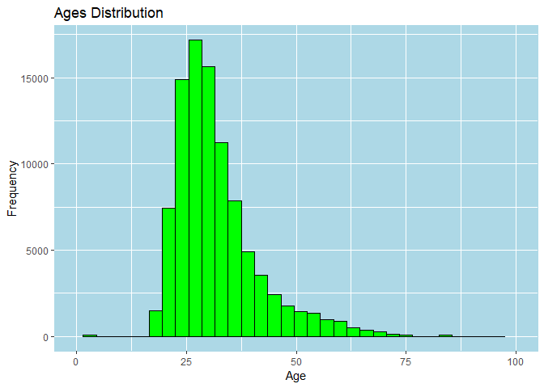

```r
# Split 4 different groups according to ages
happy_under25<-happy[c(happy$age<25),]
happy_25_30<-happy[c(25<=happy$age&happy$age<30),]
happy_30_40<-happy[c(30<=happy$age&happy$age<40),]
happy_40above<-happy[c(happy$age>=40),]
```

# Step 4: Creating Bag of Words

I created bag of word for each age group by using my own fucnction $bagwordcount$.

```r
# Write a function to calculate the frequencies of words in text
bagwordcount<-function(df){
  bag_word <- df %>%
    unnest_tokens(word,text)
  word_count <- bag_word %>%
    count(word, sort = T)
  return(word_count)
}

# Calculate words'frequencies in each age group
word_All<-bagwordcount(happy)
word_under25<-bagwordcount(happy_under25)
word_25_30<-bagwordcount(happy_25_30)
word_30_40<-bagwordcount(happy_30_40)
word_40above<-bagwordcount(happy_40above)
datatable(head(word_under25,6))
```

|  | word | n |
| --- | --- | --- |
| 1 | friend | 2471 |
| 2 | day | 1910 |
| 3 | time | 1799 |
| 4 | moment | 883 |
| 5 | played | 777 |
| 6 | family | 758 |

```r
datatable(head(word_25_30,6))
```

|  | word | n |
| --- | --- | --- |
| 1 | friend | 3506 |
| 2 | day | 2930 |
| 3 | time | 2917 |
| 4 | family | 1432 |
| 5 | feel | 1389 |
| 6 | home | 1287 |

```r
datatable(head(word_30_40,6))
```

|  | word | n |
| --- | --- | --- |
| 1 | day | 3159 |
| 2 | friend | 3141 |
| 3 | time | 3077 |
| 4 | family | 1568 |
| 5 | watched | 1497 |
| 6 | son | 1453 |

```r
datatable(head(word_40above,6))
```

|  | word | n |
| --- | --- | --- |
| 1 | time | 1381 |
| 2 | day | 1362 |
| 3 | friend | 1207 |
| 4 | daughter | 1031 |
| 5 | son | 1022 |
| 6 | husband | 766 |

# Step 5: WordCloud for 4 age groups

The wordclouds (Excluded friend,day and time) show that in each age group, which word appears most frequently, the larger the word is, the more frequently the word appears.

### Word Cloud of age group under 25

```r
wordcloud2(word_under25[4:18,], size = 0.3, minSize = 0, gridSize =  0,
    fontFamily = 'Segoe UI', fontWeight = 'bold',
    color = 'random-dark', backgroundColor = "white",
    minRotation = -pi/4, maxRotation = pi/4, shuffle = TRUE,
    rotateRatio = 0.4, shape = 'circle', ellipticity = 0.65,
    widgetsize = NULL, figPath = NULL, hoverFunction = NULL)
```

[interactive chart not shown]

It is easy to realize that the under25 wordcloud. Since the people in this group are either students or young labor. Their interests are basically, game, play, love, enjoy, girlfriend and school. Therefore, we can see that in the word cloud, these words contribute the most frequencies.

### Word Cloud of age group 25~30

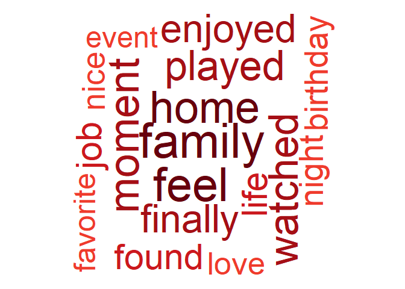

```r
wordcloud(word_25_30$word[4:30], word_25_30$n[4:30],
          scale=c(5,0.5),
          max.words=30,
          min.freq=300,
          random.order=FALSE,
          rot.per=0.3,
          use.r.layout=T,
          random.color=F，
          colors=brewer.pal(9,"Reds"))
```

There are not much difference between the wordcloud of “25~30” and “under 25”. Since the people in this age group are majority young labors. They basically have the samilar interets as the people in the group under 25. We can see a lot of common word between these two wordclouds. Such as “moment”, “job”, “love” and “family” and so on. But the word “school” disappears in the wordcloud.

### Word Cloud of age group 30~40

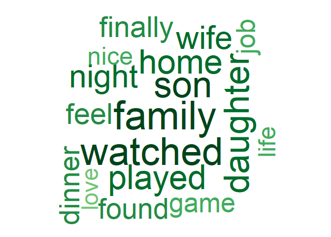

```r
wordcloud(word_30_40$word[4:30], word_25_30$n[4:30],
          scale=c(5,0.5),
          max.words=30,
          min.freq=300,
          random.order=FALSE,
          rot.per=0.3,
          use.r.layout=T,
          random.color=F，
          colors=brewer.pal(9,"Greens"))
```

### Word Cloud of age group 40 above

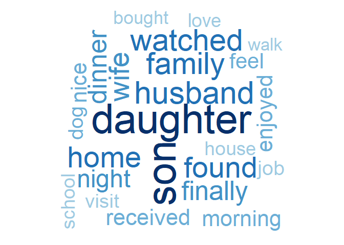

```r
wordcloud(word_40above$word[4:30], word_40above$n[4:30],
          scale=c(5,0.5),
          max.words=30,
          min.freq=300,
          random.order=FALSE,
          rot.per=0.3,
          use.r.layout=T,
          random.color=F，
          colors=brewer.pal(9,"Blues"))
```

The wordcloud of “40above” group is similar to the wordcloud of “30~40”. This result is rationally correct, since the people in these group are still parents. But “son” and “daughter” contribute the most two frequencies in this group. This may be indicate that old parents care more about their children.

# Step 6: NRC Words Sentiment Analysis

In this step, I created NRC word setiments histogram for each age group, I want to compare the sentiments distributions among 4 groups.

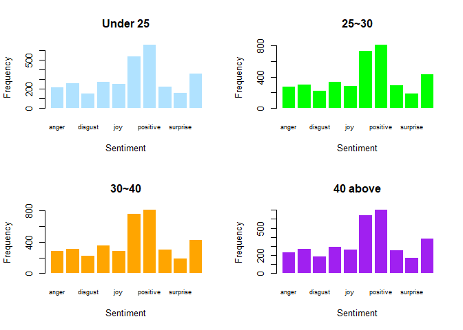

From the histograms, we saw that the sentiments distributions for 4 groups are simillar. “Positive” and “Negative” words are the most 2 common categories among all of the 4 groups. “surprise” and “disgust” appear less frequent among all of the 4 groups. The other categries in all of the 4 groups are relatively close to each other.

# Step 7: Topic Modeling

Beside the sentiments analysis, I did basic topic modeling for the 4 groups. First is to create a document term matrix.

```r
# Generate document-term matirx
doc<-rbind(paste(happy_under25$text,collapse = " "),paste(happy_25_30$text,collapse = " "),
           paste(happy_30_40$text,collapse = " "),paste(happy_40above$text,collapse = " "))

corpus<- Corpus(VectorSource(doc))
dtm <- DocumentTermMatrix(corpus)
rownames(dtm)<-c("under 25","25~30","30~40","40above")
```

After generating the document-term-matrix, I start to run LDA. In this step, I choose to have 7 topics since the original dataset $happy$ has 7 predicted_categories.

```r
# Set parameters for Gibbs sampling
burnin<-4000
iter<-2000
thin<-500
seed <-list(2003,5,63,100001,765)
nstart<-5
best<-TRUE
#Number of topics
k <- 7
#Run LDA using Gibbs sampling for group under 25
ldaOut <- LDA(dtm, k, method="Gibbs", control = list(burnin = burnin,iter = iter,
                                                                              thin = thin, seed = seed,
                                                                              nstart = nstart,best = best))
```

After running LDA, I checkd the per-document-per-word probability for each group.

```r
# per-document-per-word probability
group_gamma<-tidy(ldaOut, matrix = "gamma")
datatable(group_gamma)
```

|  | document | topic | gamma |
| --- | --- | --- | --- |
| 1 | under 25 | 1 | 0.118739399244953 |
| 2 | 25~30 | 1 | 0.0210015926050198 |
| 3 | 30~40 | 1 | 0.00680348542740845 |
| 4 | 40above | 1 | 0.00459653614993421 |
| 5 | under 25 | 2 | 0.500843956885703 |
| 6 | 25~30 | 2 | 0.454492611163358 |
| 7 | 30~40 | 2 | 0.344857549971874 |
| 8 | 40above | 2 | 0.233280877698353 |
| 9 | under 25 | 3 | 0.294955408436833 |
| 10 | 25~30 | 3 | 0.312785420496559 |

[output cut: 18 more lines]

For example, the first number under “gamma” means that a word generate from Topic 1 in “Under25” group has a probability of 0.11874.

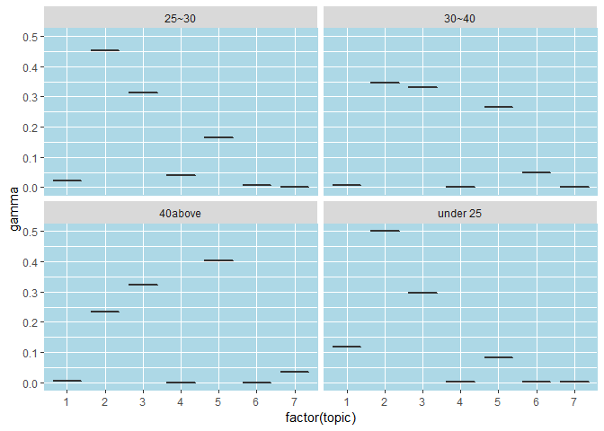

```r
# Visulize the per-document-per-word probability
group_gamma%>%
  ggplot(aes(factor(topic),gamma))+
  geom_boxplot()+
  theme(panel.background = element_rect(fill = "lightblue",
                                colour = "lightblue",
                                size = 0.5, linetype = "solid"),
        panel.grid.major = element_line(size = 0.5, linetype = 'solid',
                                colour = "white"),
        panel.grid.minor = element_line(size = 0.25, linetype = 'solid',
                                colour = "white"))+
  facet_wrap(~document)
```

The graph shows the topic probability for each group. For example, in the group of “Under25”, Topic 2 has the most probability which has a value about 0.5. This tells us that nearly half of the words in group Under 25 are from Topic 2. But we do not know what exactly the Topic 2 is, therfore I created a wordcloud for the 7 topics.

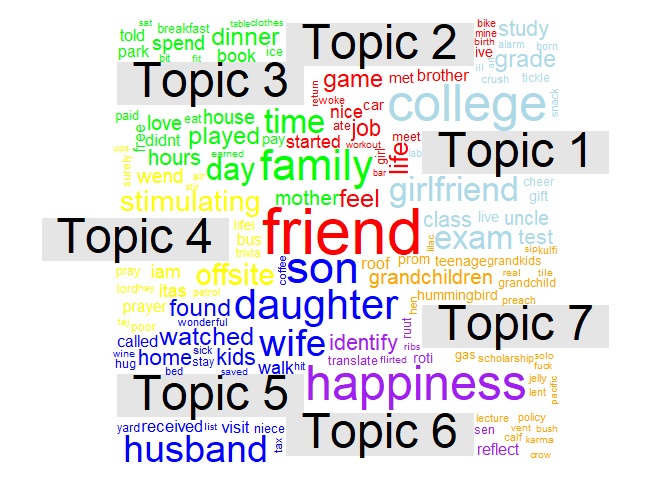

# Finally, write out results

I wrote some results for my further study in Excel format.

```r
#words to topics
ldaOut.topics <- as.matrix(topics(ldaOut,1))
write.csv(ldaOut.topics,file=paste("../output/LDAGibbs",k,"WordsToTopics.csv"))

#Top terms in each topic
ldaOut.terms <- as.matrix(terms(ldaOut,30))
write.csv(ldaOut.terms,file=paste("../output/LDAGibbs",k,"TopicsToTerms.csv"))

#probabilities associated with each topic assignment
topicProbabilities <- as.matrix(ldaOut@gamma)
write.csv(topicProbabilities,file=paste("../output/LDAGibbs",k,"TopicsProbabilities.csv"))
datatable(ldaOut.topics)
```

|  | V1 |
| --- | --- |
| under 25 | 2 |
| 25~30 | 2 |
| 30~40 | 2 |
| 40above | 5 |

```r
datatable(ldaOut.terms)
```

| Topic 1 | Topic 2 | Topic 3 | Topic 4 | Topic 5 | Topic 6 | Topic 7 |
| --- | --- | --- | --- | --- | --- | --- |
| college | friend | family | temple | son | happiness | grandson |
| girlfriend | day | time | colleagues | daughter | define | granddaughter |
| exam | time | day | offsite | wife | emotional | grandchildren |
| summer | moment | played | stimulating | husband | wellbeing | roof |
| boyfriend | feel | dinner | wend | watched | research | hummingbird |
| graduation | life | hours | smartphone | found | psychological | prom |
| grade | game | school | iam | home | identify | teenage |
| semester | enjoyed | house | itas | kids | virtue | gas |
| accepted | job | mother | occasion | morning | philosophical | scholarship |
| class | home | love | bus | finally | concepts | grandchild |

[output cut: 20 more lines]